# Visualizing Time Series Data in R

El segundo curso en el programa de Análisis de Series de Tiempo de DataCamp

Raquel Arcos Bulos

2019-12-17

## Introducción

Este documento reúne los gráficos generados en el curso [Visualizing Time Series Data in R](https://www.datacamp.com/courses/visualizing-time-series-data-in-r) de [DataCamp](https://www.datacamp.com/), el cual forma parte del programa [Time Series with R](https://www.datacamp.com/tracks/time-series-with-r) de esta compañía dedicada a la capacitación en Ciencia de Datos.

Los ejemplos están principalmente enfocados a aplicaciones financieras pero, una vez aprendidas las técnicas de procesamiento y visualización, es posible trabajar con datos para las ciencias sociales. Se requieren las librerías de R: `xts`, `zoo`, `TTR` y `Performance Analytics`. El diseño especial de los gráficos se logra gracias a la última.

El trabajo tiene por objeto construir un archivo en [R Markdown](https://rmarkdown.rstudio.com/index.html) que pueda ser visto como una página web por los visitantes de `GitHub` sin que deban descargar ningún archivo o correr código en R. El usuario en `GitHub` es Raquel-Arcos.

La conexión entre *R Studio* y `GitHub` se realizó utilizando los implementos que el IDE tiene para ello, lo que reduce sustancialmente la posibilidad de cometer errores al actualizar los archivos.

## Los datos

- El primer archivo contiene los precios de acciones diarios de cuatro importantes compañías: Yahoo, Microsoft, Citigroup y Dow Chemical en el periodo enero-2015 a diciembre-2016 (dos años).

```
##            yahoo microsoft citigroup dow_chemical
## 2015-01-02 50.17  44.30501  53.45259     42.48209
## 2015-01-05 49.13  43.89759  51.76803     41.16821
## 2015-01-06 49.21  43.25329  49.94556     40.50662
```

```
##            yahoo microsoft citigroup dow_chemical
## 2016-12-28 38.73     62.99  59.86861        57.90
## 2016-12-29 38.64     62.90  59.21050        57.42
## 2016-12-30 38.67     62.14  59.26035        57.22
```

A continuación se presentan los cuatro gráficos de series de tiempo.

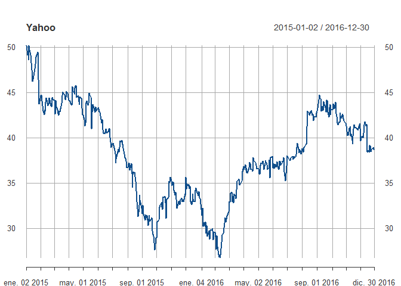

Gráfica_1

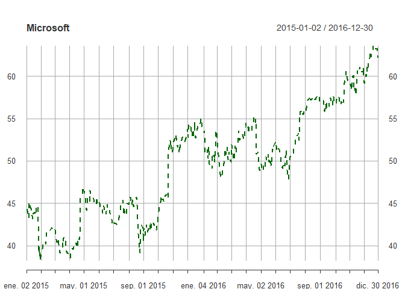

Gráfica_2

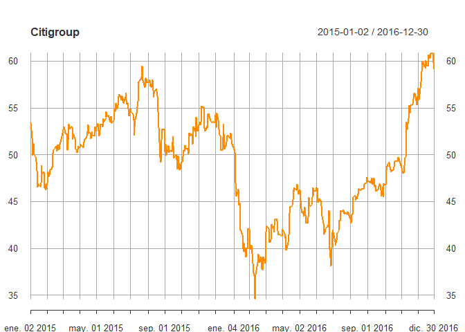

Gráfica_3

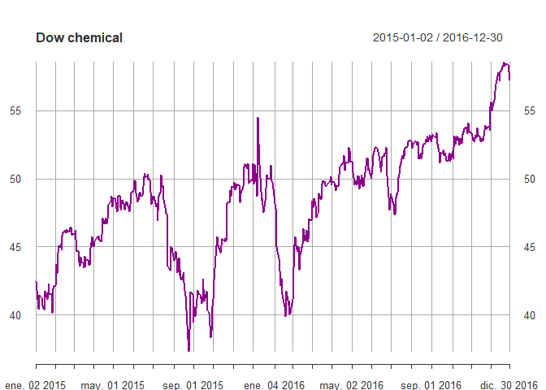

Gráfica_4

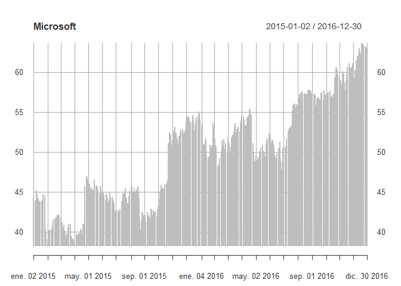

Gráfica_5

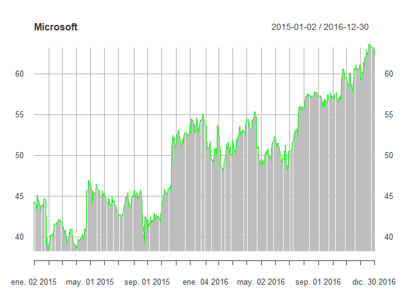

Gráfica_5

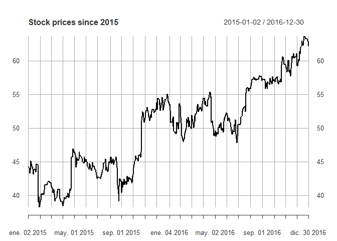

Gráfica_6

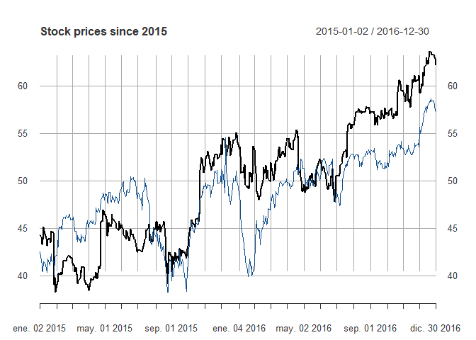

Gráfica_6

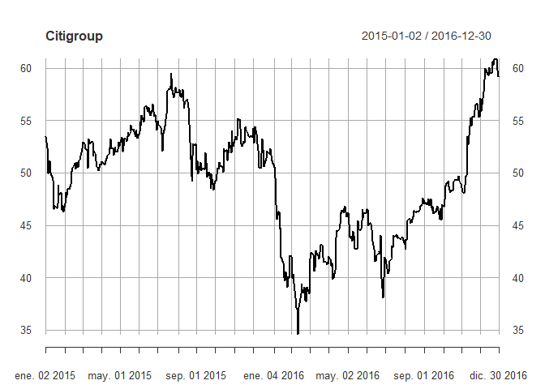

Gráfica_7

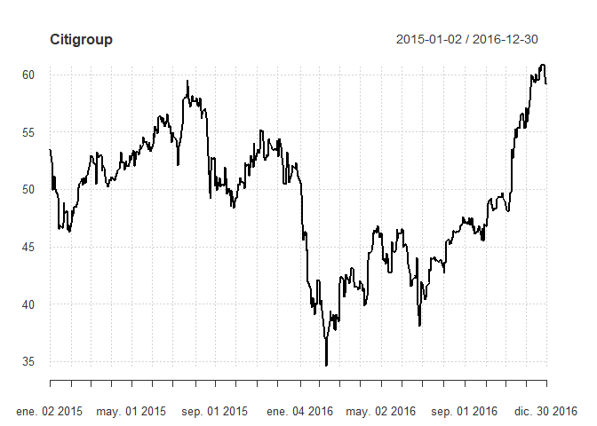

Gráfica_8

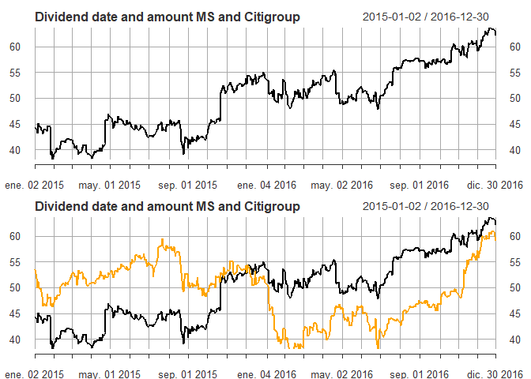

Gráfica_10

- El segundo conjunto de datos contiene los precios diarios de acciones de la compañía Apple del 2 de enero de 2015 al 27 de enero de 2017.

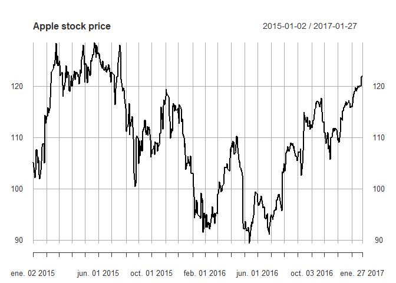

Gráfica_11

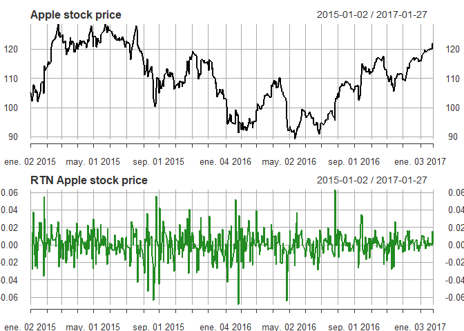

Gráfica_12

Para observar la distribución de los retornos de los precios de las acciones de la compañía Apple, elaboramos un histograma de los mismos junto con la función de densidad correspondiente.

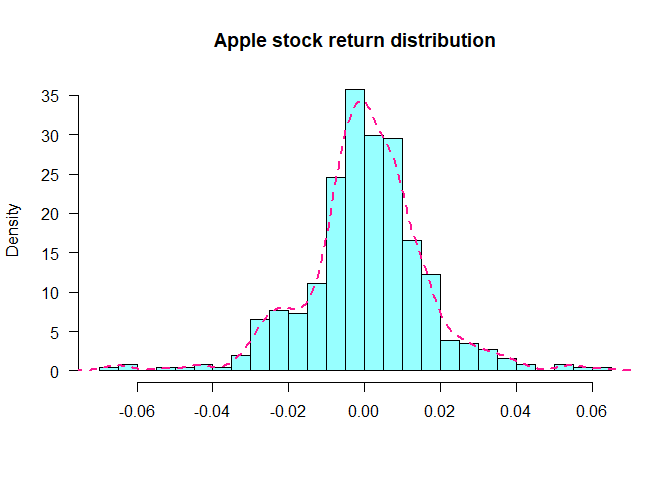

Gráfica_13

[figure not shown]

Gráfica_14

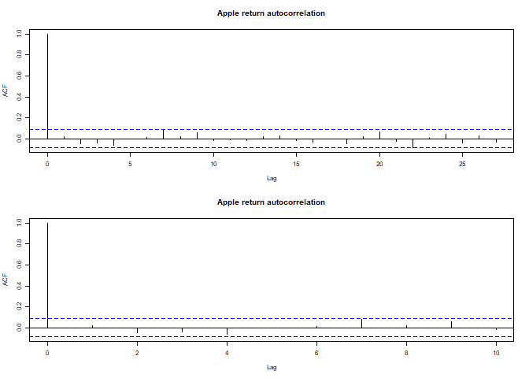

Gráfica_15

Un gráfico **q-q plot** contrasta los cuantiles de un primer conjunto de datos con los de un segundo conjunto de datos. Se usa para estudiar si los datos de interés se asemejan a una distribucion normal. Si los datos de interés siguen aproximadamente una distribución normal, los puntos en el gráfico se apegarán a una recta diagonal. Esta vía es útil para verificar de forma visual la normalidad, pero no es una prueba estadística.

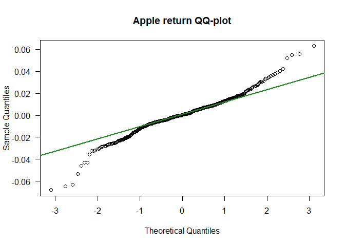

Gráfica_16

- El tercer conjunto de datos contiene los retornos diarios de los precios de las acciones de la compañía estadounidense ExxonMobil del 5 de enero de 2015 al 30 de diciembre de 2016. En seguida se visualizan los cuatro gráficos estudiados para realizar un diagnóstico de series de tiempo.

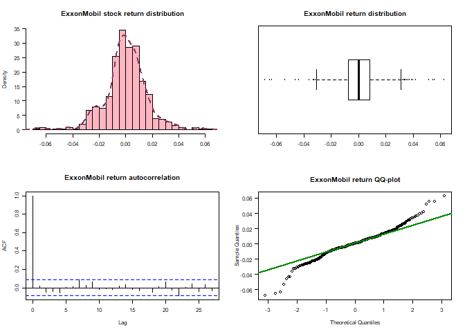

Gráfica_17